# Techniki Wizualizacji Danych - PD4

Patryk Wróbel

**Cel zadania**

Celem zadania jest przygotowanie wykresu na podstawie danych dotyczących Wszystkich Świętych lub Halloween w dwóch wersjach: w skali szarości i w kolorze i porównanie ich ze sobą.

**Wybór danych**

Wybrane dane dotyczą wydatków w USA w latach 2010-2017 przeznaczonych na kostiumy na Halloween.

Link do danych: https://www.statista.com/statistics/275741/us-halloween-costume-expenditure/ .

**Prezentacja danych**

Poniżej przedstawione są dane w formie wykresu liniowego w czterech wariantach.

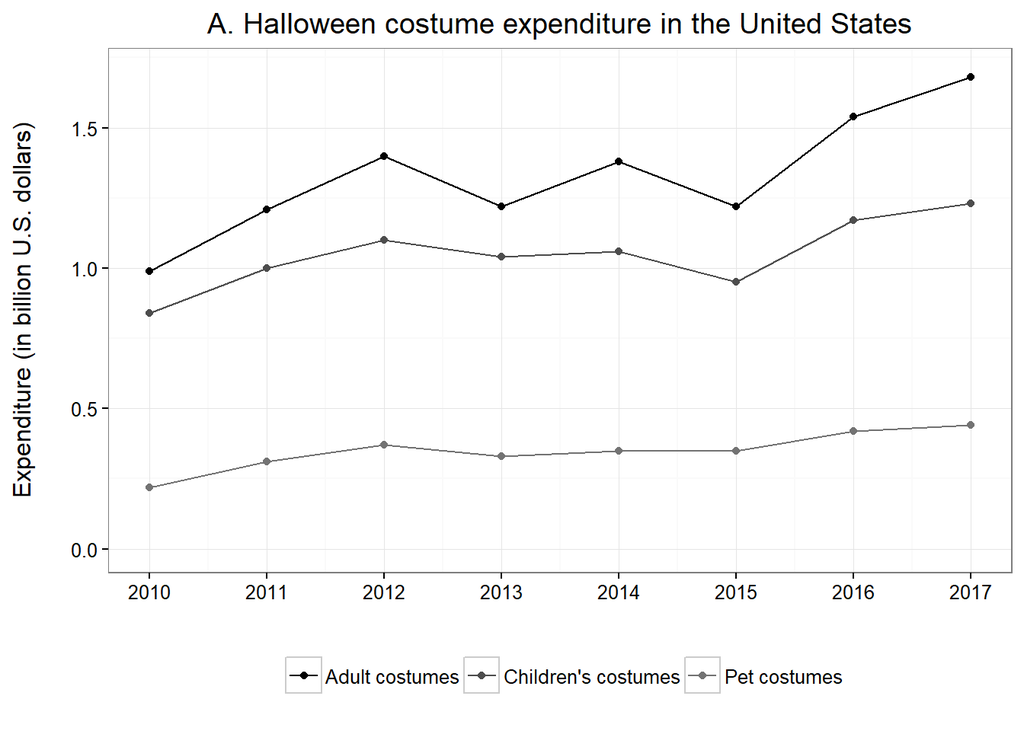

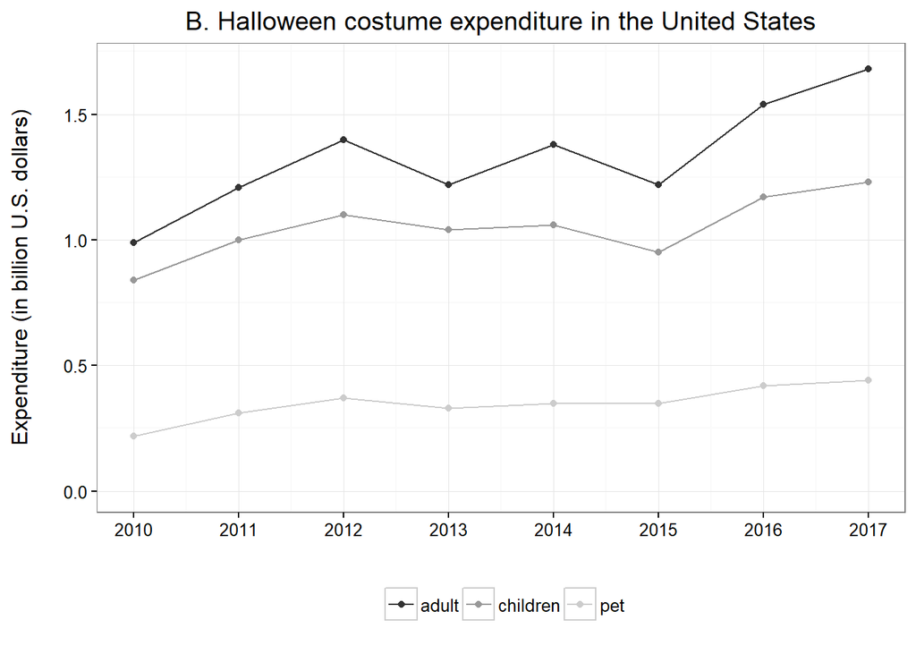

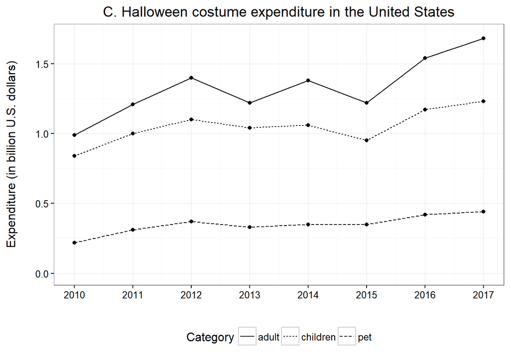

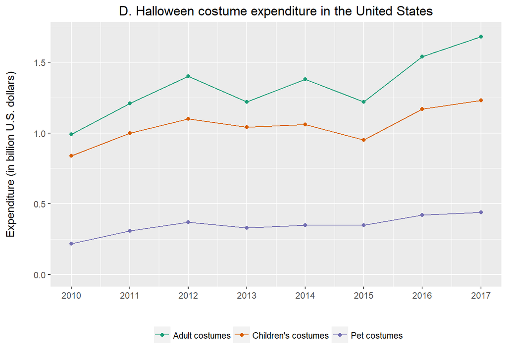

Wykresy A i B wykorzystują skalę szarości, wykres C biel i czerń, natomiast wykres D dysponuje kolorami.

W przypadku **wykresu B** szare linie reprezentujące poszczególne kategorie są co prawda rozróżnialne między sobą, jednak najjaśniejszy odcień szarości jest bardzo słabo widoczny na wykresie.

W **wykresie C** wykorzystano inny sposób rozróżnienia grup i zastosowano przerywane linie. Rozwiązanie jest czytelne i zdecydowanie wypada najlepiej na tle dwóch pierwszych wykresów. Problemem, który pojawiłby się w przypadku wystąpienia większej ilości kategorii, jest mocno ograniczona ilość rozróżnialnych typów linii.

**Wykres D** dysponuje pełną paletą barw, każdej grupie danych przyporządkowany jest kolor łatwy do rozpoznania w legendzie. Wykres jest czytelny i odporny na problem wystąpienia kolejnych grup danych (wspomniany przy wykresie C).